# Mixed Integer Programming

Joao Neto

December 2016

Ref:

- [ompr site](https://dirkschumacher.github.io/ompr/)

```r
# to install
devtools::install_github("dirkschumacher/ompr")
devtools::install_github("dirkschumacher/ompr.roi")
install.packages("ROI")
install.packages("ROI.plugin.glpk")
```

```r
library(tidyverse)
library(ROI)
library(ROI.plugin.glpk)
library(ompr)
library(ompr.roi)
```

Dirk Schumacher is the author of the `ompr` package for mixed integer linear program optimization.

For `ompr` a mixed integer linear program (MIP) is specified by:

- a set of decision variables (integer, continuous or binary)
- a set of linear constraints
- an objective linear function (to maximize or minimize)

The package functions create immutable copies of the models which can be piped to each other using the `%>%` operator.

Some available options (these are not properly sensible MIPs, only egs of use):

```r
MIPModel() %>%
  add_variable(x, type = "integer") %>%
  add_variable(y, type = "continuous") %>%
  add_variable(z, type = "binary")

MIPModel() %>%
  add_variable(x, lb = 10) %>%
  add_variable(y, lb = 5, ub = 10)  # lower and upper bounds

MIPModel() %>%
  add_variable  (x[i], i = 1:10) %>%  # creates 10 decision variables
  set_objective (x[5]) %>%
  add_constraint(x[5] <= 10)

MIPModel() %>%
  add_variable  (x[i], i = 1:3) %>%
  set_objective (sum_expr(x[i], i = 1:3)) %>%      # sum over a subset of variables
  add_constraint(sum_expr(x[i], i = 1:3) <= 10)

MIPModel() %>%
  # Create x_{i, j} variables for all combinations of i and j where
  # i = 1:10 and j = 1:10.
  add_variable(x[i, j], type = "binary", i = 1:10, j = 1:10) %>%

  # add a y_i variable for all i between 1 and 10 with i mod 2 = 0
  add_variable(y[i], type = "binary", i = 1:10, i %% 2 == 0) %>%

  # we maximize all x_{i,j} where i = j + 1
  set_objective(sum_expr(x[i, j], i = 1:10, j = 1:10, i == j + 1)) %>%

  # for each i between 1 and 10 with i mod 2 = 0
  # we add a constraint \sum_j x_{i,j}
  add_constraint(sum_expr(x[i, j], j = 1:10) <= 1, i = 1:10, i %% 2 == 0) %>%

  # of course you can leave out filters or add more than 1
  add_constraint(sum_expr(x[i, j], j = 1:10) <= 2, i = 1:10)
```

# The Knapsack Problem

Here’s its definition:

$$\begin{equation*}
\begin{array}{ll@{}ll}
\text{max} & \displaystyle\sum\limits_{i=1}^{n} v_{i}x_{i} & &\\
\text{subject to}& \displaystyle\sum\limits_{i=1}^{n} w_{i}x_{i} \leq W, & &\\
& x_{i} \in \{0,1\}, &i=1 ,\ldots, n&
\end{array}
\end{equation*}$$

In the `opmr` model we defined like this:

```r
# some data
v <- c(1.0, 4.0, 2.0, 3.0, 5.0) # each item's value
w <- c(3.1, 1.1, 2.0, 1.0, 4.0) # each item's weight
n <- length(v)                  # how many items
W <- 6                          # the knapsack's capacity

MIPModel() %>%
  add_variable  (x[i], i = 1:n, type = "binary") %>%
  set_objective (sum_expr(v[i] * x[i], i = 1:n)) %>%
  add_constraint(sum_expr(w[i] * x[i], i = 1:n) <= W) -> model
```

We can now solve the problem and access the results:

```r
model %>%
  solve_model(with_ROI("glpk")) %>%
  get_solution(x[i]) %>%
  filter(value > 0)
```

```
##   variable i value
## 1        x 2     1
## 2        x 3     1
## 3        x 4     1
```

# The Traveling Salesman Problem

Let’s create some random cities

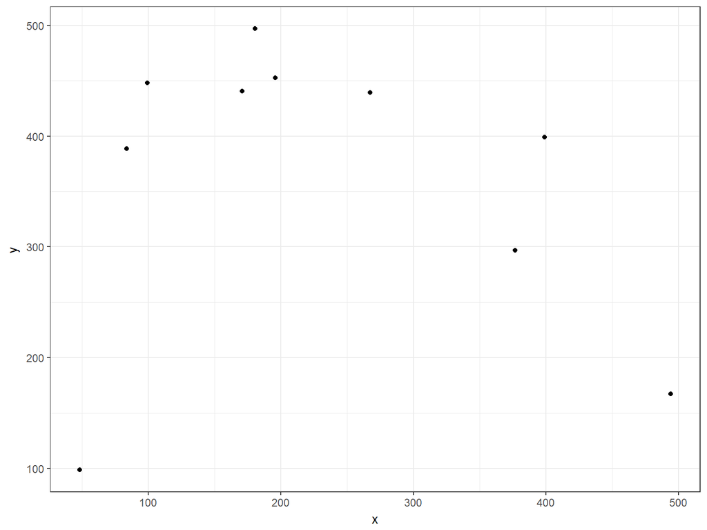

```r
n <- 10
max_x <- 500
max_y <- 500

set.seed(123456)
cities <- data.frame(id = 1:n, x = runif(n, max = max_x), y = runif(n, max = max_y))

# define the matrix distance
distance <- as.matrix(dist(select(cities, x, y), diag = TRUE, upper = TRUE))

ggplot(cities, aes(x, y)) + theme_bw() +
  geom_point()
```

Schumacher uses, in his [solution](https://dirkschumacher.github.io/ompr/articles/problem-tsp.html), the Miller–Tucker–Zemlin (MTZ) [formulation](https://www.unc.edu/~pataki/papers/teachtsp.pdf) which has quadratic many constraints and variables (so, not suitable for large `n`).

```r
model <- MIPModel() %>%
  # we create a variable that is 1 iff we travel from city i to j
  add_variable(x[i, j], i = 1:n, j = 1:n, type = "integer", lb = 0, ub = 1) %>%

  # a helper variable for the MTZ formulation of the tsp
  add_variable(u[i], i = 1:n, lb = 1, ub = n) %>%

  # minimize travel distance
  set_objective(sum_expr(distance[i, j] * x[i, j], i = 1:n, j = 1:n), "min") %>%

  # you cannot go to the same city
  set_bounds(x[i, i], ub = 0, i = 1:n) %>%

  # leave each city
  add_constraint(sum_expr(x[i, j], j = 1:n) == 1, i = 1:n) %>%

  # visit each city
  add_constraint(sum_expr(x[i, j], i = 1:n) == 1, j = 1:n) %>%

  # ensure no subtours (arc constraints)
  add_constraint(u[i] >= 2, i = 2:n) %>%
  add_constraint(u[i] - u[j] + 1 <= (n - 1) * (1 - x[i, j]), i = 2:n, j = 2:n)
```

With the model specified, we can ask the package to solve it:

```r
result <- solve_model(model, with_ROI(solver = "glpk", verbose = TRUE))
```

```
## <SOLVER MSG>  ----
## GLPK Simplex Optimizer, v4.47
## 110 rows, 110 columns, 434 non-zeros
##       0: obj =  0.000000000e+000  infeas = 2.900e+001 (20)
## *    33: obj =  2.510999794e+003  infeas = 0.000e+000 (1)
## *    68: obj =  1.450925576e+003  infeas = 5.243e-017 (1)
## OPTIMAL SOLUTION FOUND
## GLPK Integer Optimizer, v4.47
## 110 rows, 110 columns, 434 non-zeros
## 100 integer variables, 90 of which are binary
## Integer optimization begins...
## +    68: mip =     not found yet >=              -inf        (1; 0)
## +    99: >>>>>  1.469860058e+003 >=  1.450925576e+003   1.3% (3; 0)
## +   132: mip =  1.469860058e+003 >=     tree is empty   0.0% (0; 5)
## INTEGER OPTIMAL SOLUTION FOUND
## <!SOLVER MSG> ----
```

```r
solution <- get_solution(result, x[i, j]) %>%
  filter(value > 0)
solution
```

```
##    variable  i  j value
## 1         x  1  7     1
## 2         x 10  8     1
## 3         x  2  1     1
## 4         x  3  5     1
## 5         x  4  6     1
## 6         x  5  4     1
## 7         x  6 10     1
## 8         x  7  3     1
## 9         x  8  9     1
## 10        x  9  2     1
```

Let’s preprocess the result to plot it accordingly:

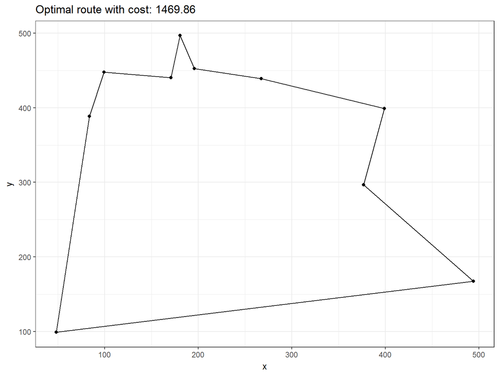

```r
paths <- select(solution, i, j) %>%
  rename(from = i, to = j) %>%
  mutate(trip_id = row_number()) %>%
  tidyr::gather(property, idx_val, from:to) %>%
  mutate(idx_val = as.integer(idx_val)) %>%
  inner_join(cities, by = c("idx_val" = "id"))

ggplot(cities, aes(x, y)) + theme_bw() +
  geom_point() +
  geom_line(data = paths, aes(group = trip_id)) +
  ggtitle(paste0("Optimal route with cost: ", round(objective_value(result), 2)))
```

# Sodoku

Variable $x_{i,j,k}$ is a binary value stating if number $k$ is at position $(i,j)$.

```r
n <- 9
model <- MIPModel() %>%

  # The number k stored in position i,j
  add_variable(x[i, j, k], i = 1:n, j = 1:n, k = 1:9, type = "binary") %>%

  # no objective
  set_objective(0) %>%

  # only one number can be assigned per cell
  add_constraint(sum_expr(x[i, j, k], k = 1:9) == 1, i = 1:n, j = 1:n) %>%

  # each number is exactly once in a row
  add_constraint(sum_expr(x[i, j, k], j = 1:n) == 1, i = 1:n, k = 1:9) %>%

  # each number is exactly once in a column
  add_constraint(sum_expr(x[i, j, k], i = 1:n) == 1, j = 1:n, k = 1:9) %>%

  # each 3x3 square must have all numbers
  add_constraint(sum_expr(x[i, j, k], i = 1:3 + sx, j = 1:3 + sy) == 1,
                 sx = seq(0, n - 3, 3), sy = seq(0, n - 3, 3), k = 1:9)
```

We can now solve the model:

```r
result <- solve_model(model, with_ROI(solver = "glpk", verbose = TRUE))
```

```
## <SOLVER MSG>  ----
## GLPK Simplex Optimizer, v4.47
## 324 rows, 729 columns, 2916 non-zeros
##       0: obj =  0.000000000e+000  infeas = 3.240e+002 (324)
## *   337: obj =  0.000000000e+000  infeas = 0.000e+000 (108)
## OPTIMAL SOLUTION FOUND
## GLPK Integer Optimizer, v4.47
## 324 rows, 729 columns, 2916 non-zeros
## 729 integer variables, all of which are binary
## Integer optimization begins...
## +   337: mip =     not found yet <=              +inf        (1; 0)
## +  1187: >>>>>  0.000000000e+000 <=  0.000000000e+000   0.0% (46; 0)
## +  1187: mip =  0.000000000e+000 <=     tree is empty   0.0% (0; 91)
## INTEGER OPTIMAL SOLUTION FOUND
## <!SOLVER MSG> ----
```

```r
result %>%
  get_solution(x[i,j,k]) %>%
  filter(value > 0) %>%
  select(i, j, k) %>%
  tidyr::spread(j, k) %>%
  select(-i) %>%
  write.table(row.names = FALSE, col.names = FALSE)
```

```
## 7 3 2 9 1 6 5 8 4
## 1 5 9 7 4 8 3 2 6
## 8 4 6 2 3 5 1 7 9
## 9 8 7 6 2 1 4 5 3
## 4 6 3 8 5 9 7 1 2
## 2 1 5 3 7 4 9 6 8
## 6 7 1 4 9 2 8 3 5
## 3 9 8 5 6 7 2 4 1
## 5 2 4 1 8 3 6 9 7
```

If we want to force some positions, just add constraints:

```r
model %>%
  add_constraint(x[1, 1, 5] == 1) %>%   # the upper left cell must be a 5
  solve_model(with_ROI(solver = "glpk")) %>%
  get_solution(x[i,j,k]) %>%
  filter(value > 0) %>%
  select(i, j, k) %>%
  tidyr::spread(j, k) %>%
  select(-i) %>%
  write.table(row.names = FALSE, col.names = FALSE)
```

```
## 5 3 2 4 8 6 1 9 7
## 8 9 1 2 5 7 3 6 4
## 6 7 4 3 1 9 8 2 5
## 1 4 3 6 9 5 2 7 8
## 2 6 7 8 3 4 5 1 9
## 9 5 8 7 2 1 4 3 6
## 7 1 5 9 4 3 6 8 2
## 4 8 6 1 7 2 9 5 3
## 3 2 9 5 6 8 7 4 1
```

# The Warehouse Location Problem

> Given a set of customers and set of locations to build warehoses the task is to decide where to build warehouses and from what warehouses goods should be shipped to which customer.

> Thus there are two decisions that need to made at once: where and if to build warehouses and the assignment of customers to warehouses. This simple setting also implies that at least one warehouse must be built and that any warehouse is big enough to serve all customers.

> As a practical example: you run the logistics for an NGO and want to regularly distribute goods to people in need. You identified a set of possible locations to set up your distribution hubs, but you are not sure where to build them. Then such a model might help. In practice however you might need to incorporate additional constraints into the model. [ref](https://dirkschumacher.github.io/ompr/articles/problem-warehouse-location.html)

$$\begin{equation*}
\begin{array}{ll@{}ll}
\text{min} & \displaystyle\sum\limits_{i=1}^{n}\sum\limits_{j=1}^{m}\operatorname{transportcost}_{i,j} \cdot x_{i, j} + \sum\limits_{j=1}^{m}\operatorname{fixedcost}_{j} \cdot y_{j}& &\\
\text{subject to} & \displaystyle\sum\limits_{j=1}^{m} x_{i, j} = 1 & i=1 ,\ldots, n&\\
& \displaystyle x_{i, j} \leq y_j, & i=1 ,\ldots, n & j=1 ,\ldots, m&\\
& x_{i,j} \in \{0,1\} &i=1 ,\ldots, n, & j=1 ,\ldots, m \\
& y_{j} \in \{0,1\} &j=1 ,\ldots, m&
\end{array}
\end{equation*}$$

Let’s make a dataset:

```r
set.seed(1234)
grid_size <- 1000
n <- 100
customer_locations <- data.frame(
  id = 1:n,
  x = round(runif(n) * grid_size),
  y = round(runif(n) * grid_size)
)

m <- 20
warehouse_locations <- data.frame(
  id = 1:m,
  x = round(runif(m) * grid_size),
  y = round(runif(m) * grid_size)
)
fixedcost <- round(rnorm(m, mean = grid_size * 10, sd = grid_size * 5))

transportcost <- function(i, j) {
  customer <- customer_locations[i, ]
  warehouse <- warehouse_locations[j, ]
  round(sqrt((customer$x - warehouse$x)^2 + (customer$y - warehouse$y)^2))
}
```

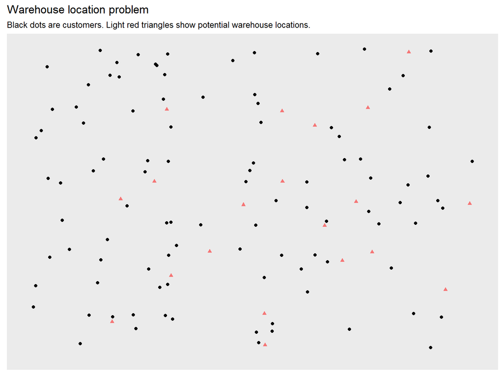

```r
p <- ggplot(customer_locations, aes(x, y)) +
  geom_point() +
  geom_point(data = warehouse_locations, color = "red", alpha = 0.5, shape = 17) +
  scale_x_continuous(limits = c(0, grid_size)) +
  scale_y_continuous(limits = c(0, grid_size)) +
  theme(axis.title = element_blank(),
        axis.ticks = element_blank(),
        axis.text = element_blank(), panel.grid = element_blank())
p + ggtitle("Warehouse location problem",
          "Black dots are customers. Light red triangles show potential warehouse locations.")
```

```r
model <- MIPModel() %>%
  # 1 iff i gets assigned to warehouse j
  add_variable(x[i, j], i = 1:n, j = 1:m, type = "binary") %>%

  # 1 iff warehouse j is built
  add_variable(y[j], j = 1:m, type = "binary") %>%

  # maximize the preferences
  set_objective(sum_expr(transportcost(i, j) * x[i, j], i = 1:n, j = 1:m) +
                  sum_expr(fixedcost[j] * y[j], j = 1:m), "min") %>%

  # every customer needs to be assigned to a warehouse
  add_constraint(sum_expr(x[i, j], j = 1:m) == 1, i = 1:n) %>%

  # if a customer is assigned to a warehouse, then this warehouse must be built
  add_constraint(x[i,j] <= y[j], i = 1:n, j = 1:m)
```

```r
solve_model(model, with_ROI(solver = "glpk", verbose = TRUE)) %>%
  get_solution(x[i,j]) %>%
  filter(value > .9) %>%
  select(i, j) -> matching
```

```
## <SOLVER MSG>  ----
## GLPK Simplex Optimizer, v4.47
## 2100 rows, 2020 columns, 6000 non-zeros
##       0: obj =  0.000000000e+000  infeas = 1.000e+002 (100)
## *   352: obj =  5.223300000e+004  infeas = 0.000e+000 (2)
## *   500: obj =  5.223300000e+004  infeas = 0.000e+000 (1)
## *  1000: obj =  5.223300000e+004  infeas = 0.000e+000 (0)
## *  1400: obj =  3.322200000e+004  infeas = 0.000e+000 (0)
## OPTIMAL SOLUTION FOUND
## GLPK Integer Optimizer, v4.47
## 2100 rows, 2020 columns, 6000 non-zeros
## 2020 integer variables, all of which are binary
## Integer optimization begins...
## +  1400: mip =     not found yet >=              -inf        (1; 0)
## +  1400: >>>>>  3.322200000e+004 >=  3.322200000e+004   0.0% (1; 0)
## +  1400: mip =  3.322200000e+004 >=     tree is empty   0.0% (0; 1)
## INTEGER OPTIMAL SOLUTION FOUND
## <!SOLVER MSG> ----
```

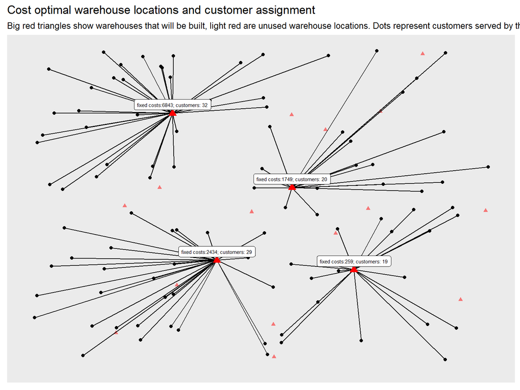

```r
plot_assignment <- matching %>%
  inner_join(customer_locations, by = c("i" = "id")) %>%
  inner_join(warehouse_locations, by = c("j" = "id"))
customer_count <- matching %>% group_by(j) %>% summarise(n = n()) %>% rename(id = j)
plot_warehouses <- warehouse_locations %>%
  mutate(costs = fixedcost) %>%
  inner_join(customer_count, by = "id") %>%
  filter(id %in% unique(matching$j))
p +
  geom_segment(data = plot_assignment, aes(x = x.y, y = y.y, xend = x.x, yend = y.x)) +
  geom_point(data  = plot_warehouses, color = "red", size = 3, shape = 17) +
  ggrepel::geom_label_repel(data  = plot_warehouses,
                            aes(label = paste0("fixed costs:", costs, "; customers: ", n)),
                            size = 2, nudge_y = 20) +
  ggtitle(paste0("Cost optimal warehouse locations and customer assignment"),
          "Big red triangles show warehouses that will be built, light red are unused warehouse locations. Dots represent customers served by the respective warehouses.")
```

The fixed costs for setting up the 4 warehouses is:

```r
sum(fixedcost[unique(matching$j)])
```

```
## [1] 11285
```